← Voltar ao Portal

[figure not shown]

Programa 414

# Síntese Avaliativa do Desempenho dos Programas do PPA Bahia 2024–2027

# **1 - Desempenho Global do Programa**

Este documento apresenta uma Síntese Avaliativa do Desempenho do Programa do Plano Plurianual - PPA 2024- 2027, trazendo uma visão estratégica dos seus resultados, de forma sintética, transparente e colaborativa. Serão levados em consideração o Indicador Sintético de Desempenho do Programa (ISDP), a evolução dos Indicadores de Programa, a eficácia das metas dos Indicadores de Compromisso, o desempenho da execução orçamentária-financeira e da execução física das Ações orçamentárias. O ISDP é uma síntese dessas quatro dimensões, destacando o desempenho do programa em relação aos resultados obtidos e aos esforços despendidos.  
Adicionalmente, são apresentados os principais resultados alcançados, evidenciando os avanços e conformidades dos cinco programas com melhores resultados, além das oportunidades de melhoria dos cinco, com menores resultados. Enquanto neste documento a análise abrange o programa e seus componentes de maneira sintética, nos demais relatórios, a análise detalhada evidencia o comportamento dos componentes do PPA por programas e por órgãos (https://www.ba.gov.br/seplan/monitoramento-e-avaliacao/avaliacao-do-ppa). Além desta Síntese, o [Painel BI - Boletim de Avanços e Oportunidades de Melhoria](https://app.powerbi.com/view?r=eyJrIjoiN2Q0ODliNDItZDFjZi00MGM1LTliNGEtODVmZDAwZTQ1OGEyIiwidCI6IjRjZDgzNWY0LTU0NDAtNDA4Zi05M2EzLTk3NWZjMTdjMzg0YSIsImMiOjR9) oferece informações organizadas em uma perspectiva estratégica do desempenho consolidado dos programas, detalhando, no entanto, cada componente avaliado. A análise nesta seção engloba o programa e seus componentes conforme segue:

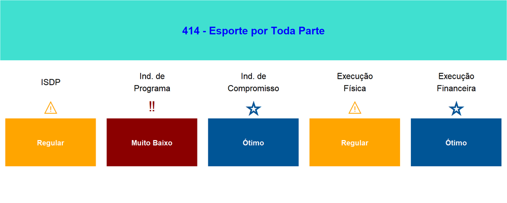

# **2 - Avanços e Conformidades no Programa**

**Indicadores de Programa:** No programa 414 - Esporte por Toda Parte, nenhum indicador apresentou evolução positiva.  
**Indicadores de Compromisso:** No programa 414 - Esporte por Toda Parte, todos os indicadores de compromisso foram avaliados como apresentando desempenho bom ou ótimo, destacando-se o indicador “2 - Número de atividades de esporte educacional e de participação e lazer realizadas”, que atingiu 100,09%. Essa performance pode ser atribuída a fatores operacionais, especialmente ao aumento no número de atividades realizadas e concluídas no ano, resultante da intensificação das ações vinculadas às iniciativas de esportes educacionais e de lazer. Além disso, o indicador “2 - Número de municípios beneficiados com projetos voltados para atletas de alto desempenho” alcançou 108,33%, impulsionado pelo aumento dos recursos orçamentários e financeiros disponíveis. O incremento nos recursos, incluindo a ampliação do incentivo fiscal do Programa FazAtleta, possibilitou a execução de mais projetos e eventos em diversos municípios, ampliando o alcance das ações e superando as expectativas estabelecidas na meta do PPA.  
**Ações Orçamentárias:** No Programa 414 - Esporte por Toda Parte, 80% das ações apresentaram bom ou ótimo desempenho financeiro, e 58,8% foram classificadas como de bom ou ótimo desempenho na execução física. A Ação 5031 - Promoção de Atividade de Esporte Educacional e Lazer obteve classificação ótima em ambas as execuções.

# **3 - Oportunidade de Melhoria no Programa**

**Indicadores de Programa:** Entretanto, no programa 414 - Esporte por Toda Parte, houve uma evolução negativa em 100% dos indicadores. O indicador 2262, que mede o número de municípios beneficiados pelas ações do programa, diminuiu em 20,07% devido a impedimentos operacionais relacionados à natureza plurianual das ações do programa. A análise considerou apenas os municípios com entregas concluídas no exercício, de acordo com os registros consolidados no Sistema FIPLAN, desconsiderando municípios com ações ainda em execução que teriam impacto no resultado.  
**Indicadores de Compromisso:** No programa 414 - Esporte por Toda Parte, nenhum dos indicadores de compromisso foi classificado como de desempenho baixo ou muito baixo.  
**Ações Orçamentárias:** No entanto, no Programa 414 - Esporte por Toda Parte, 13,3% das ações apresentaram desempenho regular na execução financeira, e 41,1% foram classificadas com baixo ou muito baixo desempenho na execução física. A ação 5628 - Capacitação de Gestor Público de Esporte e Lazer teve ambas as execuções como “Muito Baixo”.

Desenvolvido por: DAP – Diretoria de Avaliação de Políticas Públicas